# 09_ratio_between_points

## 09_ratio_between_points

#### Question

1. Consider the two points:
   - Point $A$ is at $(38,91)$
   - Point $B$ is at $(83,16)$

   A third [collinear](https://en.wikipedia.org/wiki/Collinearity) point, $C$, is 40% of the way from point $A$ to point $B$, as shown below. .

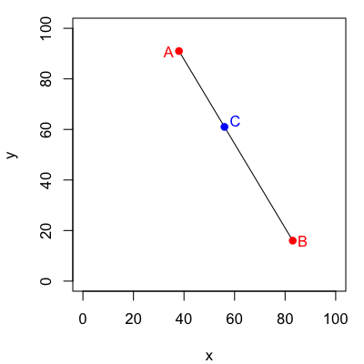

   Find the coordinates of point $C$:

   (,)

#### Question

2. Consider the two points:
   - Point $A$ is at $(41,38)$
   - Point $B$ is at $(81,28)$

   A third [collinear](https://en.wikipedia.org/wiki/Collinearity) point, $C$, is 40% of the way from point $A$ to point $B$, as shown below. .

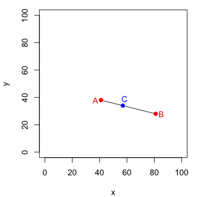

   Find the coordinates of point $C$:

   (,)

#### Question

3. Consider the two points:
   - Point $A$ is at $(24,32)$
   - Point $B$ is at $(44,72)$

   A third [collinear](https://en.wikipedia.org/wiki/Collinearity) point, $C$, is 40% of the way from point $A$ to point $B$, as shown below. .

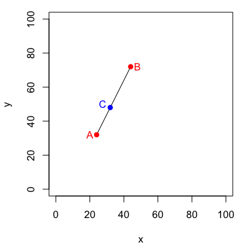

   Find the coordinates of point $C$:

   (,)

#### Question

4. Consider the two points:
   - Point $A$ is at $(36,18)$
   - Point $B$ is at $(56,68)$

   A third [collinear](https://en.wikipedia.org/wiki/Collinearity) point, $C$, is 20% of the way from point $A$ to point $B$, as shown below. .

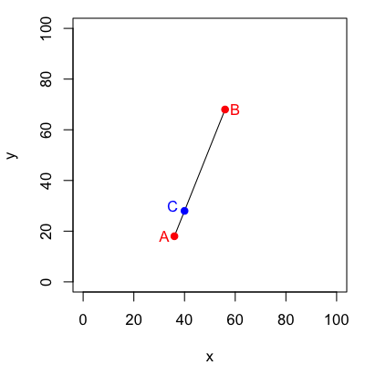

   Find the coordinates of point $C$:

   (,)

#### Question

5. Consider the two points:
   - Point $A$ is at $(47,63)$
   - Point $B$ is at $(77,43)$

   A third [collinear](https://en.wikipedia.org/wiki/Collinearity) point, $C$, is 60% of the way from point $A$ to point $B$, as shown below. .

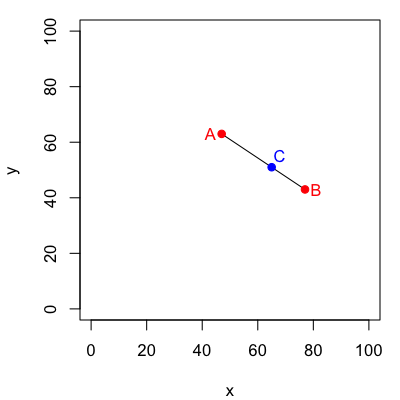

   Find the coordinates of point $C$:

   (,)

#### Question

6. Consider the two points:
   - Point $A$ is at $(53,64)$
   - Point $B$ is at $(83,24)$

   A third [collinear](https://en.wikipedia.org/wiki/Collinearity) point, $C$, is 80% of the way from point $A$ to point $B$, as shown below. .

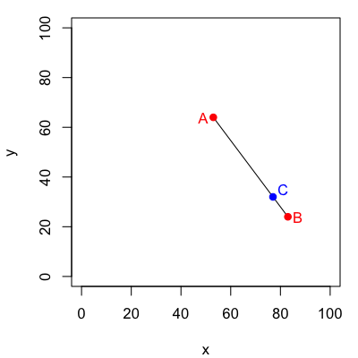

   Find the coordinates of point $C$:

   (,)

#### Question

7. Consider the two points:
   - Point $A$ is at $(20,87)$
   - Point $B$ is at $(80,67)$

   A third [collinear](https://en.wikipedia.org/wiki/Collinearity) point, $C$, is 40% of the way from point $A$ to point $B$, as shown below. .

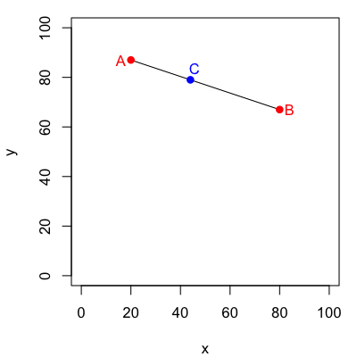

   Find the coordinates of point $C$:

   (,)

#### Question

8. Consider the two points:
   - Point $A$ is at $(9,45)$
   - Point $B$ is at $(84,75)$

   A third [collinear](https://en.wikipedia.org/wiki/Collinearity) point, $C$, is 80% of the way from point $A$ to point $B$, as shown below. .

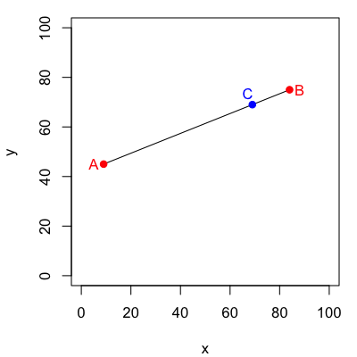

   Find the coordinates of point $C$:

   (,)